# AnalysisReport_Exp2A

DawnHan

2026-01-04

# Research Question: Do Attractive Face Bias Moral Judgments?

## Basic Info

**Research type:** Experimental, quantitative  
**Role:** End-to-end (survey design -> data collection -> data cleaning -> analysis -> interpretation)  
**Methods:** Scale construction, reliability analysis, t-tests, effect sizes, mediation  
**Analysis:** t-tests, reliabilities, mediational path analysis **Tools:** R, tidyverse, ggplot2, lavaan, R Markdown

## Why this matters

People often infer trustworthiness, ethics, and credibility from visual cues.  
This project tests whether **perceived attractiveness systematically biases moral judgments**, and whether this effect is explained by assumptions about warmth and vanity.

## Data & Experimental Design

Participants were randomly assigned to view either a **high-attractiveness** or **low-attractiveness** target profile.  
They then rated the target on attractiveness, morality, immorality, and vanity using multi-item scales presented in random order. Items in each measure were also randomly ordered.

## Analysis

### 1. Setup

#### Load Libraries

```r
####libraries####
library(psych)
library(forcats)
library(plyr)
library(dplyr)
library(tidyr)
library(purrr)
library(tibble)
library(gtsummary)
library(ggplot2)
library(ggsignif)
library(semPlot)
library(semptools)
library(kableExtra)#for HTML formatted table
library(rstatix) #get_summary_stats
library(lavaan) #for mediation
```

#### Read data

```r
#Read data
dat <- read.csv("Data_Exp2A.csv")
```

#### Preview of data

```r
head(dat,5)
```

```
##   Subjectnum AttntCheck1 AttntCheck2 attract xGender       face vain_vain
## 1          1           0           1     mod  female       X002         5
## 2          2           1          NA    high    male X029033101         1
## 3          3           1          NA    high  female X009027112         5
## 4          4           1          NA     mod    male       X117         3
## 5          5           1          NA    high  female X039100124         3
##   vain_egotistical vain_self.center character_ethical character_principled
## 1                4                5                 3                    4
## 2                2                1                 6                    6
## 3                5                5                 5                    4
## 4                3                3                 4                    4
## 5                3                3                 5                    5
##   character_honest character_trustworthy character_unethical
## 1                3                     5                   5
## 2                6                     6                   1
```

[output cut: 21 more lines]

### 2. Prepare Variables

All composite measures were created by averaging scale items after reliability checks.

Morality Measure Composition: We compute Morality as the average of two measures (trait-level & global) to create a single index for analysis. This approach integrates both trait-level and global moral judgments while preserving equal weighting across scales.

```r
# Factor coding for categorical variables
dat$attract <- factor(dat$attract, levels = c("mod","high"))
dat <- dat %>%
  mutate(attract = fct_recode(attract,
                             "moderate"  = "mod",
                             "high" = "high")) # change label for better readability
levels(dat$attract) <-list("moderate"=1, "high"=2) #set levels for later contrast coding
dat$Gender <- factor(dat$Gender)
levels(dat$Gender) <-list("male"=1,"female"=2,"prefer not to say"=3,"other"=4)  #set levels for later contrast coding
dat$xGender <- factor(dat$xGender)
levels(dat$xGender) <-list("male"=1,"female"=2)  #set levels for later contrast coding
dat$face <-factor(dat$face)

# reverse-code negatively keyed items
dat <- dat %>%
  mutate(across(
    c("character_unethical", "character_unprincipled",
      "character_dishonest", "character_untrustworthy", "moral_immorally"),
    ~ 8 - .x,
    .names = "{.col}_r"
  ))

#Aggregate variables
dat$vain <- rowMeans(
  dplyr::select(dat, starts_with("vain_")),
  na.rm = TRUE
)
dat$warm <- rowMeans(
  dplyr::select(dat, starts_with("warm_")),
  na.rm = TRUE
)

dat <- dat %>%
  rowwise() %>%
  mutate(
    Mcharacter =
      mean(
      c(character_ethical, character_principled, character_honest, character_trustworthy,
        character_unethical_r, character_unprincipled_r, character_dishonest_r,
        character_untrustworthy_r
        ), na.rm = TRUE
      ),
    Moral = mean(c(moral_morally, moral_immorally_r), na.rm = TRUE)
  ) %>%
  ungroup()

dat$Morality <- rowMeans(dat[,c("Mcharacter","Moral")], na.rm =TRUE)
```

### 3. Descriptives, and Reliabilities

Note: We focus on the primary constructs used in hypothesis testing.

#### Descriptives

```r
dat %>%
  select(attract, vain, Morality) %>%
  psych::describe() %>%
  knitr::kable(digits = 2) %>%
  kable_styling()
```

|  | vars | n | mean | sd | median | trimmed | mad | min | max | range | skew | kurtosis | se |
| --- | --- | --- | --- | --- | --- | --- | --- | --- | --- | --- | --- | --- | --- |
| attract* | 1 | 404 | 1.51 | 0.50 | 2.00 | 1.51 | 0.00 | 1.00 | 2 | 1.00 | -0.03 | -2.00 | 0.02 |
| vain | 2 | 404 | 3.92 | 1.35 | 4.00 | 3.95 | 1.48 | 1.00 | 7 | 6.00 | -0.24 | -0.52 | 0.07 |
| Morality | 3 | 404 | 4.56 | 1.11 | 4.62 | 4.61 | 1.16 | 1.31 | 7 | 5.69 | -0.31 | -0.45 | 0.06 |

#### Reliabilities

All multi-item measures showed acceptable to excellent reliability (α >= 0.83).

```r
scales <- list(
  Vanity = c("vain_vain", "vain_egotistical", "vain_self.center"),
  MoralCharacter = c("character_ethical",
                     "character_principled",
                     "character_honest",
                     "character_trustworthy",
                     "character_unethical_r",
                       "character_unprincipled_r",
                       "character_dishonest_r",
                       "character_untrustworthy_r"),
  MorallyScales = c("moral_morally", "moral_immorally_r"),
  MoralScales = c("Mcharacter", "Moral"),

  Warmth = c("warm_sociable",
             "warm_happy",
             "warm_agreeable",
             "warm_easygoing",
             "warm_playful")
)


alpha_table <- map_df(
  names(scales),
  ~{
    a <- psych::alpha(dat[, scales[[.x]]], warnings = FALSE)
    tibble(
      Construct = .x,
      Items = length(scales[[.x]]),
      Alpha = round(a$total$raw_alpha, 2)
    )
  }
)

knitr::kable(
  alpha_table,
  caption = "Scale Reliability (Cronbach’s α)"
) %>%
  kableExtra::kable_styling(full_width = FALSE)
```

Scale Reliability (Cronbach’s α)

| Construct | Items | Alpha |
| --- | --- | --- |
| Vanity | 3 | 0.93 |
| MoralCharacter | 8 | 0.96 |
| MorallyScales | 2 | 0.83 |
| MoralScales | 2 | 0.89 |
| Warmth | 5 | 0.90 |

#### Correlations

Construct-level correlations were examined to confirm expected alignment between moral and character judgments.

```r
knitr::kable(cor(dat[, c("attractive","vain","warm","Morality")],
    use = "pairwise.complete.obs"), digits = 2)%>%kable_styling()
```

|  | attractive | vain | warm | Morality |
| --- | --- | --- | --- | --- |
| attractive | 1.00 | -0.05 | 0.52 | 0.45 |
| vain | -0.05 | 1.00 | -0.19 | -0.52 |
| warm | 0.52 | -0.19 | 1.00 | 0.60 |
| Morality | 0.45 | -0.52 | 0.60 | 1.00 |

## 4. Manipulation Check: Perceived Attractiveness

### Research question

Did the attractiveness manipulation successfully change perceived attractiveness ratings?

#### Mean comparison (t-test)

```r
dat %>%
  tbl_summary(
    by = attract,
    include = attractive,
    # Force the variable to be treated as continuous
    type = list(attractive ~ "continuous"),
    statistic = list(attractive ~ "{mean} ({sd})"),
    digits = list(attractive ~ 2)
  ) %>%
  add_p(test = list(attractive ~ "t.test"))
```

| **Characteristic** | **moderate** N = 199<sup>1</sup> | **high** N = 205<sup>1</sup> | **p-value**<sup>2</sup> |
| --- | --- | --- | --- |
| attractive | 4.21 (1.35) | 5.28 (1.07) | <0.001 |

<sup>1</sup> Mean (SD)  
<sup>2</sup> Welch Two Sample t-test

### Effect size

```r
cohen.d(dat$attractive,dat$attract, alpha=.05)
```

```
## Call: cohen.d(x = dat$attractive, group = dat$attract, alpha = 0.05)
## Cohen d statistic of difference between two means
##      lower effect upper
## [1,]  0.68   0.88  1.09
##
## Multivariate (Mahalanobis) distance between groups
## [1] 0.88
## r equivalent of difference between two means
## data
##  0.4
```

**Interpretation** Participants rated targets in the high-attractiveness condition as significantly more attractive than those in the moderate-attractiveness condition, with a medium-to-large effect size. This confirms that the manipulation functioned as intended.

#### Robustness check: Does the manipulation vary by gender?

```r
fit<- lm(attractive ~ attract * xGender * Gender, data = dat)

tbl_regression(fit,
               label = list(
      attract = "Attractiveness Condition",
      xGender = "Target Gender",
      Gender  = "Participant Gender"
    ))
```

| **Characteristic** | **Beta** | **95% CI** | **p-value** |
| --- | --- | --- | --- |
| Attractiveness Condition |  |  |  |
| moderate | — | — |  |
| high | 1.4 | 0.95, 1.8 | <0.001 |
| Target Gender |  |  |  |
| male | — | — |  |
| female | 1.0 | 0.55, 1.5 | <0.001 |
| Participant Gender |  |  |  |
| male | — | — |  |
| female | 0.36 | -0.11, 0.82 | 0.13 |
| prefer not to say | 0.42 | -1.9, 2.7 | 0.7 |
| other | 1.4 | -0.88, 3.7 | 0.2 |
| Attractiveness Condition * Target Gender |  |  |  |
| high * female | -0.33 | -0.95, 0.30 | 0.3 |
| Attractiveness Condition * Participant Gender |  |  |  |
| high * female | -0.52 | -1.2, 0.14 | 0.12 |
| high * prefer not to say | -0.40 | -3.6, 2.9 | 0.8 |
| high * other |  |  |  |
| Target Gender * Participant Gender |  |  |  |
| female * female | -0.23 | -0.88, 0.42 | 0.5 |
| female * prefer not to say | -2.0 | -5.3, 1.2 | 0.2 |
| female * other |  |  |  |
| Attractiveness Condition * Target Gender * Participant Gender |  |  |  |
| high * female * female | 0.34 | -0.57, 1.3 | 0.5 |
| high * female * prefer not to say |  |  |  |
| high * female * other |  |  |  |

Abbreviation: CI = Confidence Interval

**Interpretation** No higher-order interactions meaningfully altered the main effect of attractiveness, suggesting the manipulation operated consistently across target and participant gender.

## 3. Effect of Attractiveness on Moral Judgments

### Research question

Does perceived attractiveness influence how moral or immoral a target is judged?

### Morality judgments

#### Mean comparison and effect size

```r
dat %>%
  tbl_summary(
    by = attract,
    include = Morality,
    # Force the variable to be treated as continuous
    type = list(Morality ~ "continuous"),
    statistic = list(Morality ~ "{mean} ({sd})"),
    digits = list(Morality ~ 2)
  ) %>%
  add_p(test = list(Morality ~ "t.test"))
```

| **Characteristic** | **moderate** N = 199<sup>1</sup> | **high** N = 205<sup>1</sup> | **p-value**<sup>2</sup> |
| --- | --- | --- | --- |
| Morality | 4.41 (1.18) | 4.72 (1.03) | 0.005 |

<sup>1</sup> Mean (SD)  
<sup>2</sup> Welch Two Sample t-test

### Visualization

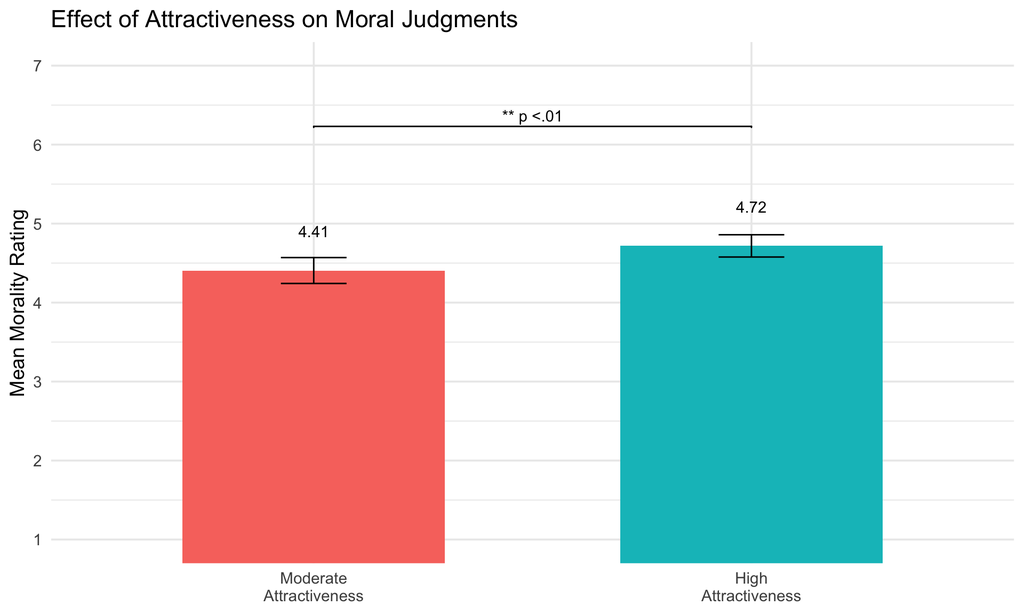

```r
tMorality <- dat %>% group_by(attract) %>%
    get_summary_stats(Morality, type ="common")

ggplot(tMorality, aes(x = attract, y = mean, fill = attract)) +
geom_col(width = .6) +
geom_errorbar(
aes(ymin = mean - ci, ymax = mean + ci),
width = .15
) +
stat_summary(
  fun = "mean",
  geom = "text",
  aes(label = after_stat(round(y, 2))),
  vjust = -3
  ) +
geom_signif(
  comparisons = list(c("moderate", "high")),
  annotations = "** p <.01",
  y_position = 6.2,
  tip_length = 0.02
)+
scale_x_discrete(labels = c("Moderate\nAttractiveness", "High\nAttractiveness")) +
scale_y_continuous(breaks = 0:7) +
coord_cartesian(ylim = c(1, 7)) +
labs(
title = "Effect of Attractiveness on Moral Judgments",
x = NULL,
y = "Mean Morality Rating"
) +
theme_minimal(base_size = 14) +
theme(legend.position = "none")
```

### Effect size

```r
cohen.d(dat$Morality, dat$attract, alpha = .05)
```

```
## Call: cohen.d(x = dat$Morality, group = dat$attract, alpha = 0.05)
## Cohen d statistic of difference between two means
##      lower effect upper
## [1,]  0.09   0.28  0.48
##
## Multivariate (Mahalanobis) distance between groups
## [1] 0.28
## r equivalent of difference between two means
## data
## 0.14
```

**Interpretation** Targets presented as highly attractive were judged as significantly more moral than moderately attractive targets, with a practically meaningful effect size.

### Robustness check: Gender effects

The main effect of attractiveness remained stable across target and participant gender.

```r
fit2 <- lm(
Morality ~ attract * Gender * xGender,
data = dat[dat$Gender %in% c("male", "female"), ]
)

tbl_regression(fit2,
               label = list(
      attract = "Attractiveness Condition",
      xGender = "Target Gender",
      Gender  = "Participant Gender"
    ))
```

| **Characteristic** | **Beta** | **95% CI** | **p-value** |
| --- | --- | --- | --- |
| Attractiveness Condition |  |  |  |
| moderate | — | — |  |
| high | 0.38 | -0.03, 0.79 | 0.073 |
| Participant Gender |  |  |  |
| male | — | — |  |
| female | 0.00 | -0.43, 0.42 | >0.9 |
| Target Gender |  |  |  |
| male | — | — |  |
| female | 0.41 | -0.01, 0.83 | 0.053 |
| Attractiveness Condition * Participant Gender |  |  |  |
| high * female | -0.07 | -0.67, 0.53 | 0.8 |
| Attractiveness Condition * Target Gender |  |  |  |
| high * female | 0.03 | -0.55, 0.60 | >0.9 |
| Participant Gender * Target Gender |  |  |  |
| female * female | 0.49 | -0.11, 1.1 | 0.11 |
| Attractiveness Condition * Participant Gender * Target Gender |  |  |  |
| high * female * female | -0.22 | -1.1, 0.63 | 0.6 |

Abbreviation: CI = Confidence Interval

## 4. Mediation: Does Vanity and Warmth Explain the Attractiveness’ Effect on Morality?

### Structural Equation Model: Dual-Path Model

A structural equation model was estimated to examine whether **attractiveness influenced perceived morality** through two parallel pathways: **vanity** and **warmth**.  
- **Attractiveness** was specified as the exogenous predictor.  
- **Vanity** and **warmth** were included as mediators.  
- Both mediators were allowed to covary to account for shared variance in evaluative judgments.

#### Define dual path model

```r
# Re-code attractiveness condition as 0/1 for better interpretability of the coefficients
dat<-dat %>%
  mutate(attract.coding = factor(attract, labels=c(0,1), levels = c("moderate","high")))

# Define dual path model
Model <- 'Morality ~ b1 * vain + b2 * warm + c * attract.coding
          vain ~ a1 * attract.coding
          warm ~ a2 * attract.coding
          indirect_vain := a1 * b1
          indirect_warm := a2 * b2
          total := c + (a1 * b1) + (a2 * b2)
          vain ~~ warm
          '
```

#### Fit SEM with bootstrap CI for indirect effects

```r
set.seed(490)
dualpath<- sem(model = Model,
                   data = dat,
                   se = "bootstrap",
                   bootstrap = 10000)
```

#### Standardized estimates & R²

```r
results.dualpath <-summary(dualpath,
        fit.measures = FALSE,
        standardize = TRUE,
        rsquare = TRUE)

results.dualpath
```

```
## lavaan 0.6-19 ended normally after 10 iterations
##
##   Estimator                                         ML
##   Optimization method                           NLMINB
##   Number of model parameters                         9
##
##   Number of observations                           404
##
## Model Test User Model:
##
##   Test statistic                                 0.000
##   Degrees of freedom                                 0
##
## Parameter Estimates:
##
##   Standard errors                            Bootstrap
##   Number of requested bootstrap draws            10000
##   Number of successful bootstrap draws            9777
##
## Regressions:
##                    Estimate  Std.Err  z-value  P(>|z|)   Std.lv  Std.all
##   Morality ~
##     vain      (b1)   -0.370    0.030  -12.131    0.000   -0.370   -0.450
##     warm      (b2)    0.461    0.033   14.055    0.000    0.461    0.490
##     attrct.cd  (c)    0.287    0.079    3.628    0.000    0.287    0.129
##   vain ~
##     attrct.cd (a1)    0.420    0.133    3.151    0.002    0.420    0.155
##   warm ~
##     attrct.cd (a2)    0.391    0.117    3.352    0.001    0.391    0.166
##
## Covariances:
##                    Estimate  Std.Err  z-value  P(>|z|)   Std.lv  Std.all
##  .vain ~~
##    .warm             -0.339    0.089   -3.835    0.000   -0.339   -0.218
##
## Variances:
##                    Estimate  Std.Err  z-value  P(>|z|)   Std.lv  Std.all
##    .Morality          0.563    0.043   13.214    0.000    0.563    0.456
##    .vain              1.785    0.107   16.726    0.000    1.785    0.976
##    .warm              1.354    0.098   13.884    0.000    1.354    0.973
##
## R-Square:
##                    Estimate
##     Morality          0.544
##     vain              0.024
##     warm              0.027
##
## Defined Parameters:
##                    Estimate  Std.Err  z-value  P(>|z|)   Std.lv  Std.all
##     indirect_vain    -0.155    0.051   -3.051    0.002   -0.155   -0.070
##     indirect_warm     0.180    0.057    3.166    0.002    0.180    0.081
##     total             0.312    0.109    2.856    0.004    0.312    0.140
```

#### CI of indirect effect using Bootstrapping

```r
parameterEstimates(dualpath, ci = TRUE, level = 0.95, boot.ci.type = "perc")
```

```
##               lhs op               rhs         label    est    se       z
## 1        Morality  ~              vain            b1 -0.370 0.030 -12.131
## 2        Morality  ~              warm            b2  0.461 0.033  14.055
## 3        Morality  ~    attract.coding             c  0.287 0.079   3.628
## 4            vain  ~    attract.coding            a1  0.420 0.133   3.151
## 5            warm  ~    attract.coding            a2  0.391 0.117   3.352
## 6            vain ~~              warm               -0.339 0.089  -3.835
## 7        Morality ~~          Morality                0.563 0.043  13.214
## 8            vain ~~              vain                1.785 0.107  16.726
## 9            warm ~~              warm                1.354 0.098  13.884
## 10 attract.coding ~~    attract.coding                0.250 0.000      NA
## 11  indirect_vain :=             a1*b1 indirect_vain -0.155 0.051  -3.051
## 12  indirect_warm :=             a2*b2 indirect_warm  0.180 0.057   3.166
## 13          total := c+(a1*b1)+(a2*b2)         total  0.312 0.109   2.856
##    pvalue ci.lower ci.upper
## 1   0.000   -0.429   -0.310
## 2   0.000    0.398    0.526
## 3   0.000    0.129    0.441
## 4   0.002    0.157    0.678
## 5   0.001    0.165    0.617
## 6   0.000   -0.511   -0.166
## 7   0.000    0.475    0.643
## 8   0.000    1.573    1.991
## 9   0.000    1.161    1.545
## 10     NA    0.250    0.250
## 11  0.002   -0.257   -0.057
## 12  0.002    0.074    0.295
## 13  0.004    0.102    0.527
```

#### Dual Path Model Plot

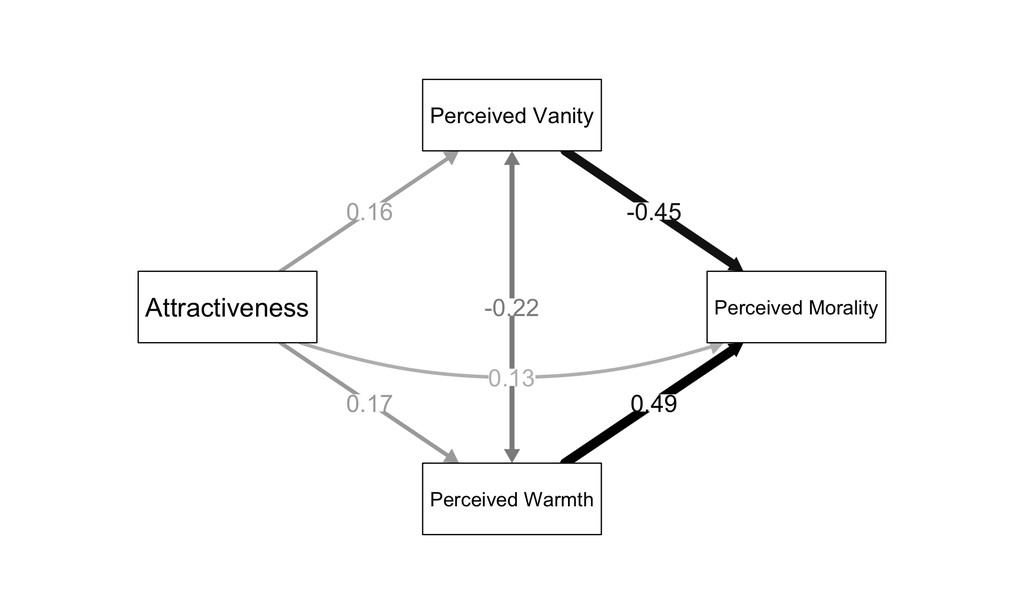

**Interpretation** Highly attractive targets were perceived as more vain and warmer.

Vanity and warmth partially mediated the effect of attractiveness on perceived morality.

The dual-path model accounts for shared variance between vanity and warmth, providing a clean, interpretable explanation of how attractiveness shapes moral impressions.